# Project: Investigate a Dataset - [The Movie Database(TMDb)]

- Introduction
- Data Wrangling
- Exploratory Data Analysis
- Conclusions

## Introduction

This project presents a detailed walkthrough, of the exploratory analysis of a movie dataset, to gain meaningful insights, and draw conclusions from the data.

### Dataset Description

This data set contains information about 10,000 movies collected from The Movie Database (TMDb), including user ratings and revenue. TMDb dataset contained 21 columns which are as follows: id  
imdb_id, popularity, budget, revenue, original_title, cast, homepage, director, tagline, keywords , overview , runtime, genres, production_companies, release_date, vote_count, vote_average, release_year, revenue_adj Through this dataset, I intend to answer some questions:

- What relationship exists among columns of the dataset
- What Genres of movies are popular?
- What are the properties of high grossing movies?
  - Is there a Relationship between high revenue movies and budget, popularity, or release_year
- What are the Trends in the number of movies released each year?
- Are movies with a high budget popular?

```python
# Use this cell to set up import statements for all of the packages that you
#   plan to use.
import numpy as np
import pandas as pd
from pandas import Series, DataFrame

from matplotlib import pyplot as plt
import seaborn as sns

%matplotlib inline

#   http://ipython.readthedocs.io/en/stable/interactive/magics.html
```

```python
# Upgrade pandas to use dataframe.explode() function.
# !pip install --upgrade pandas==0.25.0
```

## Data Wrangling

Here, the dataset was loaded into a pandas DataFrame, and the data assessed visually, and programmatically for data quality issues.

### General Properties

In total, the dataset contained 10866 rows and 21 columns, with many of the rows containing null values, which justified the cleaning of the data.

```python
# Loaded the dataSet
movies_df = pd.read_csv('Database_TMDb_movie_data/tmdb-movies.csv')
```

```python
# Visually inspected the first few rows of the dataset
movies_df.head(3)
```

|  | id | imdb_id | popularity | budget | revenue | original_title | cast | homepage | director | tagline | ... | overview | runtime | genres | production_companies | release_date | vote_count | vote_average | release_year | budget_adj | revenue_adj |
| --- | --- | --- | --- | --- | --- | --- | --- | --- | --- | --- | --- | --- | --- | --- | --- | --- | --- | --- | --- | --- | --- |
| 0 | 135397 | tt0369610 | 32.985763 | 150000000 | 1513528810 | Jurassic World | Chris Pratt\|Bryce Dallas Howard\|Irrfan Khan\|Vi... | http://www.jurassicworld.com/ | Colin Trevorrow | The park is open. | ... | Twenty-two years after the events of Jurassic ... | 124 | Action\|Adventure\|Science Fiction\|Thriller | Universal Studios\|Amblin Entertainment\|Legenda... | 6/9/15 | 5562 | 6.5 | 2015 | 1.379999e+08 | 1.392446e+09 |
| 1 | 76341 | tt1392190 | 28.419936 | 150000000 | 378436354 | Mad Max: Fury Road | Tom Hardy\|Charlize Theron\|Hugh Keays-Byrne\|Nic... | http://www.madmaxmovie.com/ | George Miller | What a Lovely Day. | ... | An apocalyptic story set in the furthest reach... | 120 | Action\|Adventure\|Science Fiction\|Thriller | Village Roadshow Pictures\|Kennedy Miller Produ... | 5/13/15 | 6185 | 7.1 | 2015 | 1.379999e+08 | 3.481613e+08 |
| 2 | 262500 | tt2908446 | 13.112507 | 110000000 | 295238201 | Insurgent | Shailene Woodley\|Theo James\|Kate Winslet\|Ansel... | http://www.thedivergentseries.movie/#insurgent | Robert Schwentke | One Choice Can Destroy You | ... | Beatrice Prior must confront her inner demons ... | 119 | Adventure\|Science Fiction\|Thriller | Summit Entertainment\|Mandeville Films\|Red Wago... | 3/18/15 | 2480 | 6.3 | 2015 | 1.012000e+08 | 2.716190e+08 |

3 rows × 21 columns

```python
# checking for missing values, and errant datatypes
movies_df.info()
```

```
<class 'pandas.core.frame.DataFrame'>
RangeIndex: 10866 entries, 0 to 10865
Data columns (total 21 columns):
id                      10866 non-null int64
imdb_id                 10856 non-null object
popularity              10866 non-null float64
budget                  10866 non-null int64
revenue                 10866 non-null int64
original_title          10866 non-null object
cast                    10790 non-null object
homepage                2936 non-null object
director                10822 non-null object
tagline                 8042 non-null object
keywords                9373 non-null object
overview                10862 non-null object
runtime                 10866 non-null int64
genres                  10843 non-null object
production_companies    9836 non-null object
release_date            10866 non-null object
vote_count              10866 non-null int64
vote_average            10866 non-null float64
release_year            10866 non-null int64
budget_adj              10866 non-null float64
revenue_adj             10866 non-null float64
dtypes: float64(4), int64(6), object(11)
memory usage: 1.7+ MB
```

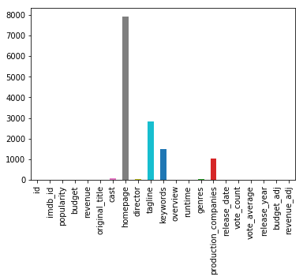

```python
# VISUALLY REPRESENTING COLUMNS WITH MISSING VALUES
movies_df.isna().sum().plot(kind="bar")
plt.show()
```

### Findings

The columns with missing values can easily be dropped as this does not directly affect the quality of the research, since they will not be useful in answering the research questions `genre` also has some missing values but would be ignored for our research purpose

```python
# getting the summary statistics of the dataset
movies_df.describe()
```

|  | id | popularity | budget | revenue | runtime | vote_count | vote_average | release_year | budget_adj | revenue_adj |
| --- | --- | --- | --- | --- | --- | --- | --- | --- | --- | --- |
| count | 10866.000000 | 10866.000000 | 1.086600e+04 | 1.086600e+04 | 10866.000000 | 10866.000000 | 10866.000000 | 10866.000000 | 1.086600e+04 | 1.086600e+04 |
| mean | 66064.177434 | 0.646441 | 1.462570e+07 | 3.982332e+07 | 102.070863 | 217.389748 | 5.974922 | 2001.322658 | 1.755104e+07 | 5.136436e+07 |
| std | 92130.136561 | 1.000185 | 3.091321e+07 | 1.170035e+08 | 31.381405 | 575.619058 | 0.935142 | 12.812941 | 3.430616e+07 | 1.446325e+08 |
| min | 5.000000 | 0.000065 | 0.000000e+00 | 0.000000e+00 | 0.000000 | 10.000000 | 1.500000 | 1960.000000 | 0.000000e+00 | 0.000000e+00 |
| 25% | 10596.250000 | 0.207583 | 0.000000e+00 | 0.000000e+00 | 90.000000 | 17.000000 | 5.400000 | 1995.000000 | 0.000000e+00 | 0.000000e+00 |
| 50% | 20669.000000 | 0.383856 | 0.000000e+00 | 0.000000e+00 | 99.000000 | 38.000000 | 6.000000 | 2006.000000 | 0.000000e+00 | 0.000000e+00 |
| 75% | 75610.000000 | 0.713817 | 1.500000e+07 | 2.400000e+07 | 111.000000 | 145.750000 | 6.600000 | 2011.000000 | 2.085325e+07 | 3.369710e+07 |
| max | 417859.000000 | 32.985763 | 4.250000e+08 | 2.781506e+09 | 900.000000 | 9767.000000 | 9.200000 | 2015.000000 | 4.250000e+08 | 2.827124e+09 |

from the table above, we can see that `runtime`, `budget`, and `revenue` have minimum values of 0. This is most likely an incorrect value, and so I will fill in the zero's as missing values

```python
# searching for duplicate data
movies_df[movies_df.duplicated()]
```

|  | id | imdb_id | popularity | budget | revenue | original_title | cast | homepage | director | tagline | ... | overview | runtime | genres | production_companies | release_date | vote_count | vote_average | release_year | budget_adj | revenue_adj |
| --- | --- | --- | --- | --- | --- | --- | --- | --- | --- | --- | --- | --- | --- | --- | --- | --- | --- | --- | --- | --- | --- |
| 2090 | 42194 | tt0411951 | 0.59643 | 30000000 | 967000 | TEKKEN | Jon Foo\|Kelly Overton\|Cary-Hiroyuki Tagawa\|Ian... | NaN | Dwight H. Little | Survival is no game | ... | In the year of 2039, after World Wars destroy ... | 92 | Crime\|Drama\|Action\|Thriller\|Science Fiction | Namco\|Light Song Films | 3/20/10 | 110 | 5.0 | 2010 | 30000000.0 | 967000.0 |

1 rows × 21 columns

From the above, it is seen that there is a single case of a duplicate value

### Data Cleaning

- Changed the `runtime` and `release_date` columns into a datetime datatype,
- Dropped duplicate rows, and columns irrelevant to the research questions,
- Replaced the zero's in `runtime`, `budget_adj`, `revenue_adj` as missing values,
- Created a `profit` column, and
- Replaced the missing values with the mean of the respective the column

```python
# dropped duplicates
movies_df.drop_duplicates(inplace=True)
```

```python
movies_df['release_date'] = pd.to_datetime(movies_df['release_date'])
```

```python
movies_df['release_date'] = movies_df['release_date'].apply(lambda x: x.strftime('%Y-%m-%d'))
```

```python
# changed the runtime column datatype to datetime
movies_df['runtime'] = pd.to_datetime(movies_df['runtime'])
```

```python
# visually inspecting the changes
movies_df['release_date'].head()
```

```
0    2015-06-09
1    2015-05-13
2    2015-03-18
3    2015-12-15
4    2015-04-01
Name: release_date, dtype: object
```

```python
# ispecting release_year
movies_df['release_year'].head()
```

```
0    2015
1    2015
2    2015
3    2015
4    2015
Name: release_year, dtype: int64
```

I will leave `release_year` to be stored as an int, as it is easier to work with

#### REPLACING 0 WITH NAN

- budget_adj
- revenue_adj
- runtime

```python
# I created a column with the above columns
# and replaced with NAN
col_with_zero = ['runtime','budget_adj','revenue_adj']
movies_df[col_with_zero] = movies_df[col_with_zero].replace(0,np.NAN)
movies_df.describe()
```

|  | id | popularity | budget | revenue | vote_count | vote_average | release_year | budget_adj | revenue_adj |
| --- | --- | --- | --- | --- | --- | --- | --- | --- | --- |
| count | 10865.000000 | 10865.000000 | 1.086500e+04 | 1.086500e+04 | 10865.000000 | 10865.000000 | 10865.000000 | 5.169000e+03 | 4.849000e+03 |
| mean | 66066.374413 | 0.646446 | 1.462429e+07 | 3.982690e+07 | 217.399632 | 5.975012 | 2001.321859 | 3.688907e+07 | 1.151009e+08 |
| std | 92134.091971 | 1.000231 | 3.091428e+07 | 1.170083e+08 | 575.644627 | 0.935138 | 12.813260 | 4.196096e+07 | 1.988557e+08 |
| min | 5.000000 | 0.000065 | 0.000000e+00 | 0.000000e+00 | 10.000000 | 1.500000 | 1960.000000 | 9.210911e-01 | 2.370705e+00 |
| 25% | 10596.000000 | 0.207575 | 0.000000e+00 | 0.000000e+00 | 17.000000 | 5.400000 | 1995.000000 | 8.102293e+06 | 1.046585e+07 |
| 50% | 20662.000000 | 0.383831 | 0.000000e+00 | 0.000000e+00 | 38.000000 | 6.000000 | 2006.000000 | 2.271505e+07 | 4.395666e+07 |
| 75% | 75612.000000 | 0.713857 | 1.500000e+07 | 2.400000e+07 | 146.000000 | 6.600000 | 2011.000000 | 5.008384e+07 | 1.316482e+08 |
| max | 417859.000000 | 32.985763 | 4.250000e+08 | 2.781506e+09 | 9767.000000 | 9.200000 | 2015.000000 | 4.250000e+08 | 2.827124e+09 |

```python
col_with_nan = ['runtime','budget_adj','revenue_adj']
movies_df[col_with_nan] = movies_df[col_with_nan].fillna(movies_df[col_with_nan].mean())
```

```python
# checking for missing values
movies_df['budget_adj'].isna().sum()
```

```
0
```

Reference: kaggle.com

```python
movies_df['profit'] = movies_df[ 'revenue_adj'] - movies_df['budget_adj']
```

```python
movies_df.columns
```

```
Index(['id', 'imdb_id', 'popularity', 'budget', 'revenue', 'original_title',
       'cast', 'homepage', 'director', 'tagline', 'keywords', 'overview',
       'runtime', 'genres', 'production_companies', 'release_date',
       'vote_count', 'vote_average', 'release_year', 'budget_adj',
       'revenue_adj', 'profit'],
      dtype='object')
```

I dropped columns containing missing values, and other columns irrelevant in answering the research questions, saving the result in a new variable, `movies_df1`

```python
# dropping columns
movies_df1 = movies_df.drop(['id', 'imdb_id', 'original_title', 'cast', 'homepage', 'director', 'budget', 'revenue', 'tagline','keywords', 'production_companies','overview','vote_count'], axis=1)
```

```python
# Visually inspecting the changes made
movies_df1.info()
```

```
<class 'pandas.core.frame.DataFrame'>
Int64Index: 10865 entries, 0 to 10865
Data columns (total 9 columns):
popularity      10865 non-null float64
runtime         10865 non-null datetime64[ns]
genres          10842 non-null object
release_date    10865 non-null object
vote_average    10865 non-null float64
release_year    10865 non-null int64
budget_adj      10865 non-null float64
revenue_adj     10865 non-null float64
profit          10865 non-null float64
dtypes: datetime64[ns](1), float64(5), int64(1), object(2)
memory usage: 848.8+ KB
```

## Exploratory Data Analysis

### Research Question 1 (What relationship exist between columns in the dataset?)

Created a subplot of all columns of the `movies_df1` dataframe

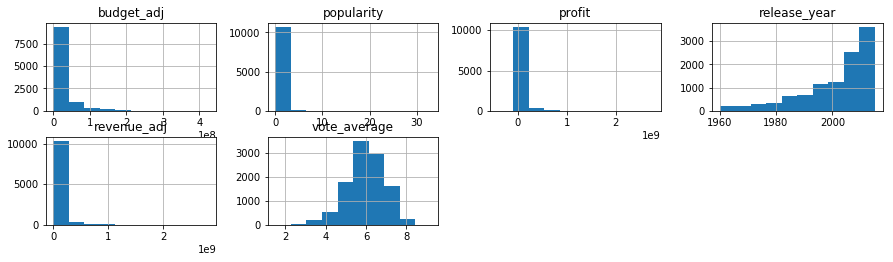

```python
# Getting of all columns in the dataset
movies_df1.hist(layout=(5,4), figsize=(15,10))
plt.show()
```

Next, I calculated the relationship between each column in the dataset, ignoring non numeric columns

```python
# checking for correlation among fields
corrMatrix = movies_df1.corr()
corrMatrix
```

|  | popularity | vote_average | release_year | budget_adj | revenue_adj | profit |
| --- | --- | --- | --- | --- | --- | --- |
| popularity | 1.000000 | 0.209517 | 0.089806 | 0.399026 | 0.509010 | 0.466412 |
| vote_average | 0.209517 | 1.000000 | -0.117576 | 0.073181 | 0.138257 | 0.135161 |
| release_year | 0.089806 | -0.117576 | 1.000000 | 0.023229 | -0.059984 | -0.071878 |
| budget_adj | 0.399026 | 0.073181 | 0.023229 | 1.000000 | 0.524507 | 0.338852 |
| revenue_adj | 0.509010 | 0.138257 | -0.059984 | 0.524507 | 1.000000 | 0.978767 |
| profit | 0.466412 | 0.135161 | -0.071878 | 0.338852 | 0.978767 | 1.000000 |

From the result of corrMatrix, we can see a Good positive correlation between revenue and budget, the revenue, and popularity of the movie. There is als a high positive corelation between the revenue of a movie and the profit Below, I represented the above graphically

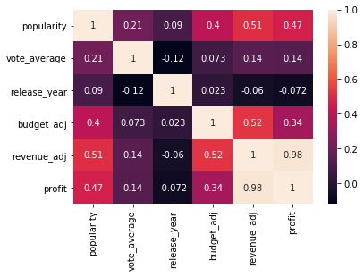

```python
import seaborn as sn
sn.heatmap(corrMatrix, annot=True)
plt.show()
```

### Research Question 2 (What genre of movies are popular?)

```python
# programmatically inspecting the popularity of different genres of movies
filt = movies_df1.groupby('genres')['popularity'].mean().sort_values(ascending=False)
```

I grouped the movies by genres, and deteremined the average popularity of each genre

```python
# visually inspecting the most popular genres
filt.head(3)
```

```
genres
Adventure|Science Fiction|Thriller    13.112507
Adventure|Drama|Science Fiction       12.699699
Science Fiction|Adventure|Thriller    10.739009
Name: popularity, dtype: float64
```

```python
# Visually inspecting the leat popular genres
filt.tail(3)
```

```
genres
Drama|Thriller|Science Fiction|Romance|Foreign    0.001983
Crime|Drama|History|Documentary                   0.001372
Mystery|Comedy|Drama                              0.000188
Name: popularity, dtype: float64
```

```python
# getting a pivot table to show the relationship between genres, and popularity
table = pd.pivot_table(data=movies_df1,index='genres',values='popularity',aggfunc=np.mean).sort_values(by='popularity', ascending=False)
table.head(3)
```

| genres | popularity |
| --- | --- |
| Adventure\|Science Fiction\|Thriller | 13.112507 |
| Adventure\|Drama\|Science Fiction | 12.699699 |
| Science Fiction\|Adventure\|Thriller | 10.739009 |

- The most popular movie genres are: Adventure|Science Fiction|Thriller
- The least popular movie genres are: Mystery|Comedy|Drama

### Research Question 3 (What Percentage of adventure movies are released each year?)

Adventures are the most popular genres. Below, I explore the percentage of Adventure movies released each year

```python
# Getting the total number of movies released each year
movies_df1['release_year'].value_counts().head(3)
```

```
2014    700
2013    659
2015    629
Name: release_year, dtype: int64
```

```python
# Grouping dataset by the number of movies released each year
movies_per_year = movies_df1.groupby(['release_year'])
```

```python
# Define a function to get the genres of movies that are adventures
def genre_type(genre):
    return genre.str.contains('Adventure').sum()
# Getting the number of movies released each year that are Adventure
adventure_per_year = movies_per_year['genres'].apply(genre_type)
```

The `adventure_per_year` variable displays the number of movies released each year whose genre is adventure. What percentage of the total number of movies released each year are Adventure?

```python
# Get the Total number of movies released each year
yearly_movies = movies_df1['release_year'].value_counts()

# and the total number of movies released each year that are Adventure
adventure_per_year = movies_per_year['genres'].apply(genre_type)
```

```python
# Getting the percentage of Adventure movies
PercentAdventure= (adventure_per_year/ yearly_movies) * 100
```

```python
# getting the year with the highest percentage of adventure movies
PercentAdventure.sort_values(ascending=False).head()
```

```
1977    26.315789
1985    25.688073
1966    23.913043
1962    21.875000
1984    20.952381
dtype: float64
```

Adventures are the most popular movies, and the above shows the percentage of adventure movies released each year

```python
# Grouping by year, and genres, to get the average popularity
group_genre = movies_df1.groupby(["release_year", "genres"])['popularity'].mean()
group_genre.head(3)
```

```
release_year  genres
1960          Action|Adventure|Drama|History|Western    0.310398
              Action|Adventure|Western                  1.872132
              Action|Drama|Foreign|History|War          0.194948
Name: popularity, dtype: float64
```

We can see the average popularity of the genres through different years

### Research Question 4 (What trends can be seen with Increasing revenue?)

Below, I analyzed the relationship that exists between revenue, budget, popularity, and the year released.

plot a scatter graph for revenue against budget, plot a histogram for revenue against popularity, plot a histogram for release date against revenue visually inspect the relatinship between revenue and genres

```python
# ReLationship between revenue and release year
movies_df1.groupby(["release_year"])['revenue_adj'].mean().sort_values(ascending=False).head(3)
```

```
release_year
1977    2.042735e+08
1967    1.953918e+08
1965    1.892346e+08
Name: revenue_adj, dtype: float64
```

The year 1977 had the highest average revenues for movies

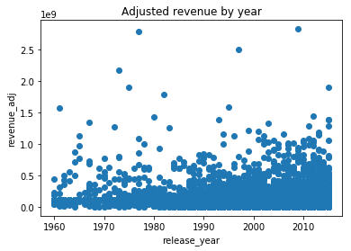

```python
# plotting the relationship between revenue and year
plt.scatter(movies_df1["release_year"], movies_df1["revenue_adj"])
plt.title('Adjusted revenue by year')
plt.xlabel('release_year')
plt.ylabel('revenue_adj')
plt.show()
```

From the graph, we see that as the year progressed, the number of movies increased but there is no significant increase in the revenue obtained from each movie

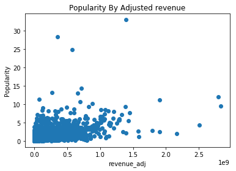

```python
# relationship between revenue and popularity
plt.scatter(movies_df1["revenue_adj"], movies_df1["popularity"])
plt.title('Popularity By Adjusted revenue')
plt.xlabel('revenue_adj')
plt.ylabel('Popularity')
plt.show()
```

From the graph above, we can see a slight increase in popularity with increasing revenue

Visually inspecting the relationship between genres and revenue

```python
# grouping by genres, and getting the average revenue for each genre
top_revenue_genres= movies_df1.groupby('genres')['revenue_adj'].mean().sort_values(ascending=False)
top_revenue_genres.head(3)
```

```
genres
Horror|Thriller|Adventure                   1.907006e+09
Science Fiction|Adventure|Family|Fantasy    1.791694e+09
Crime|Drama|Mystery|Thriller|Action         1.583050e+09
Name: revenue_adj, dtype: float64
```

The highest grossing movie genres are Horor, Thriller, and Adventures

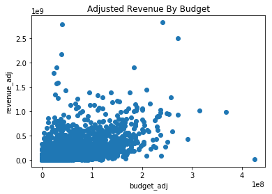

```python
# relationship between revenue and budget
plt.scatter(movies_df1["budget_adj"], movies_df1["revenue_adj"])
plt.title('Adjusted Revenue By Budget')
plt.xlabel('budget_adj')
plt.ylabel('revenue_adj')
plt.show()
```

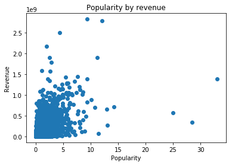

```python
# visualizing the relationship between popularity and revenue
plt.scatter(movies_df1['popularity'], movies_df1['revenue_adj'])
plt.title('Popularity by revenue')
plt.xlabel('Popularity')
plt.ylabel('Revenue')
plt.show()
```

There is a positive correlation between the popularity of a movie, and the total amount grossed. Movies that were popular, were also high grossing

There is a positive correlation between the adjusted budget, and the adjusted revenue.

```python
movies_df1.sort_values(by=["revenue_adj","budget_adj","release_year"],ascending =[False, False, True]).head(3)
```

|  | popularity | runtime | genres | release_date | vote_average | release_year | budget_adj | revenue_adj | profit |
| --- | --- | --- | --- | --- | --- | --- | --- | --- | --- |
| 1386 | 9.432768 | 1970-01-01 00:00:00.000000162 | Action\|Adventure\|Fantasy\|Science Fiction | 2009-12-10 | 7.1 | 2009 | 2.408869e+08 | 2.827124e+09 | 2.586237e+09 |
| 1329 | 12.037933 | 1970-01-01 00:00:00.000000121 | Adventure\|Action\|Science Fiction | 1977-03-20 | 7.9 | 1977 | 3.957559e+07 | 2.789712e+09 | 2.750137e+09 |
| 5231 | 4.355219 | 1970-01-01 00:00:00.000000194 | Drama\|Romance\|Thriller | 1997-11-18 | 7.3 | 1997 | 2.716921e+08 | 2.506406e+09 | 2.234714e+09 |

### Research Question 5 (Are high Budget movies popular?)

Does a high budget translate to more popularity? I take high budget movies to be movies whose adjusted buget are greaater than or equal to one million

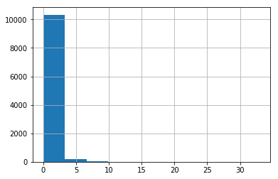

```python
# popuLArity oF High budget movies
movies_df[movies_df1['budget_adj']>=1000000]['popularity'].hist()
```

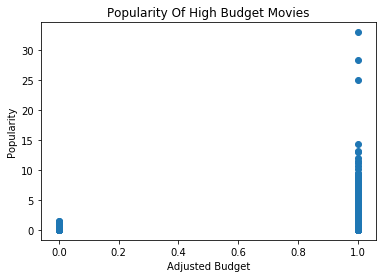

```python
x= movies_df1['budget_adj']>=1000000
y = movies_df1['popularity']
# visualizing the relationship between popularity and revenue
plt.scatter(x, y)
plt.title('Popularity Of High Budget Movies')
plt.xlabel('Adjusted Budget')
plt.ylabel('Popularity')
plt.show()
```

There is an increase in popularity with increase budget

### Research Question 6(What is the trend in profit across the years?)

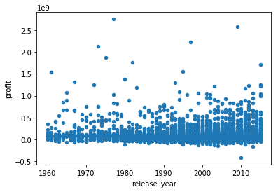

```python
# plotting a graph of profit per year
movies_df1.plot(x='release_year', y='profit', kind='scatter')
plt.show()
```

## Conclusions

```python
from subprocess import call
call(['python', '-m', 'nbconvert', 'Investigate_a_Dataset.ipynb'])
```

```
0
```